# Use of SynthETIC to Generate Individual Claims of Realistic Features

## Plot of Cumulative Claims Payments

Note that by default, similar to the case of `claim_output` and `claim_payment_inflation`, we will truncate the claims development such that payments that were projected to fall out of the maximum development period are forced to be paid at the exact end of the maximum development period allowed. This convention will cause some concentration of transactions at the end of development period $I$ (shown as a surge in claims in the $I$th period).

Users can set `adjust = FALSE` to see the “true” picture of claims development without such artificial adjustment. If the plots look significantly different, this indicates to the user that the user’s selection of lag parameters (notification and/or settlement delays) is not well matched to the maximum number of development periods allowed, and consideration might be given to changing one or the other.

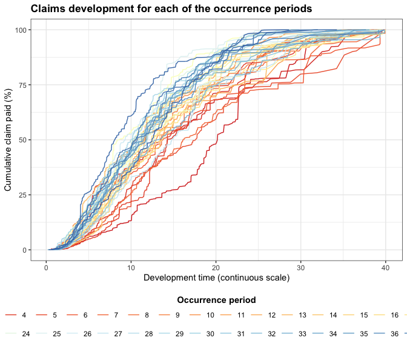

```r
plot_claims(test_transaction_dataset)
```

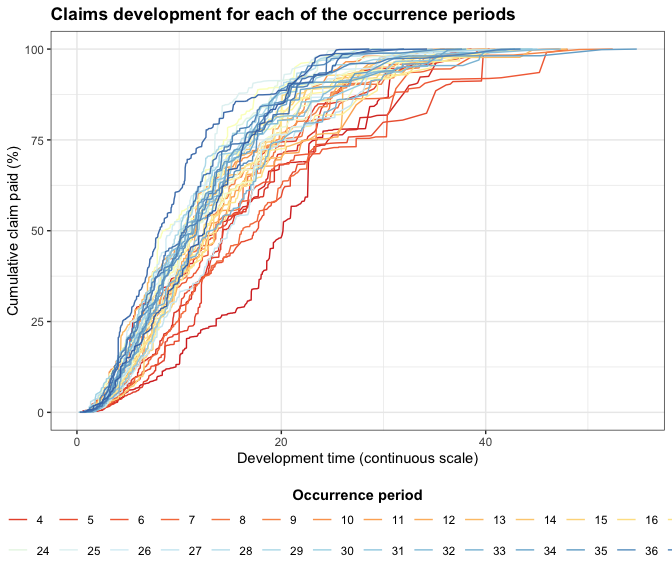

```r
# compare with the "full complete picture"
plot_claims(test_transaction_dataset, adjust = FALSE)
```

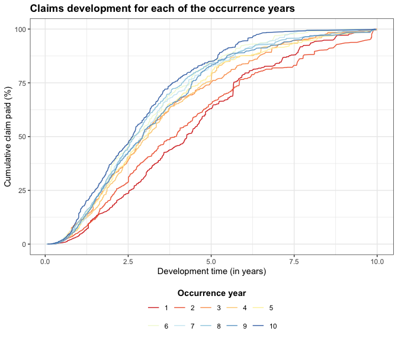

```r
# plot by occurrence and development years
plot_claims(test_transaction_dataset, by_year = TRUE)
```

## Multiple Simulation Runs

Once all the input parameters have been set up, we can repeat the simulation process as many times as desired and average the results.

```r
start.time <- proc.time()
times <- 100
results_all <- vector("list")
for (i in 1:times) {
  # Module 1: Claim occurrence
  n_vector <- claim_frequency(I, E, lambda)
  occurrence_times <- claim_occurrence(n_vector)
  # Module 2: Claim size
  claim_sizes <- claim_size(n_vector, S_df, range = c(0, 1e24))
  # Module 3: Claim notification
  notidel <- claim_notification(n_vector, claim_sizes, notidel_mean, notidel_cv)
  # Module 4: Claim settlement
  setldel <- claim_closure(n_vector, claim_sizes, setldel_mean, setldel_cv)
  # Module 5: Claim payment count
  no_payments <- claim_payment_no(n_vector, claim_sizes, simulate_no_pmt,
                                  claim_size_benchmark_1 = benchmark_1,
                                  claim_size_benchmark_2 = benchmark_2)
  # Module 6: Claim payment size
  payment_sizes <- claim_payment_size(n_vector, claim_sizes, no_payments, simulate_amt_pmt)
  # Module 7: Claim payment time
  payment_delays <- claim_payment_delay(n_vector, claim_sizes, no_payments, setldel,
                                        setldel_mean, simulate_d)
  payment_times <- claim_payment_time(n_vector, occurrence_times, notidel, payment_delays)
  # Module 8: Claim inflation
  payment_inflated <- claim_payment_inflation(
    n_vector, payment_sizes, payment_times, occurrence_times,
    claim_sizes, base_inflation_vector, SI_occurrence, SI_payment)

  results_all[[i]] <- generate_transaction_dataset(
    frequency_vector = n_vector,
    occurrence_list = occurrence_times,
    claim_size_list = claim_sizes,
    notification_list = notidel,
    settlement_list = setldel,
    no_payments_list = no_payments,
    payment_size_list = payment_sizes,
    payment_delay_list = payment_delays,
    payment_time_list = payment_times,
    payment_inflated_list = payment_inflated)
}
proc.time() - start.time
```

```r
start.time <- proc.time()
data_all <- dplyr::bind_rows(results_all)
dim(data_all)

plot_claims(data_all, by_year = FALSE, inflated = TRUE) +
  ggplot2::labs(subtitle = paste("With", times, "simulations"))
proc.time() - start.time
```

[output not shown]

```r
start.time <- proc.time()
plot_claims(data_all, by_year = TRUE, inflated = TRUE) +
  ggplot2::labs(subtitle = paste("With", times, "simulations"))
proc.time() - start.time
```

[output not shown]

```r
start.time <- proc.time()
plot_claims(data_all, by_year = FALSE, inflated = FALSE) +
  ggplot2::labs(subtitle = paste("With", times, "simulations"))
proc.time() - start.time
```

[output not shown]

```r
start.time <- proc.time()
# by year
plot_claims(data_all, by_year = TRUE, inflated = FALSE) +
  ggplot2::labs(subtitle = paste("With", times, "simulations"))
proc.time() - start.time
```

[output not shown]